# Experimental treatment with edaravone in a mouse model of spinocerebellar ataxia 1

Analysis of behaviour

Author

Martina Sucha, Simona Benediktova, Filip Tichanek, Jan Jedlicka, Stepan Kapl, Dana Jelinkova, Zdenka Purkartova, Jan Tuma, Jitka Kuncova, Jan Cendelin

This page shows R code for the study [Sucha et al.](https://www.mdpi.com/1422-0067/24/13/10689) (2023, *International Journal of Molecular Science*).

**Citation**:

> Sucha M, Benediktova S, Tichanek F, Jedlicka J, Kapl S, Jelinkova D, Purkartova Z, Tuma J, Kuncova J, Cendelin J. Experimental Treatment with Edaravone in a Mouse Model of Spinocerebellar Ataxia 1. International Journal of Molecular Sciences. 2023; 24(13):10689. https://doi.org/10.3390/ijms241310689

[GitHub page](https://github.com/filip-tichanek/edaravonSCA1): https://github.com/filip-tichanek/edaravonSCA1

# 1 Upload of packages

```r
rm(list = ls())

suppressWarnings(suppressMessages( {
library(brms)
library(beeswarm)
library(vioplot)
library(glmmTMB)
library(car)
library(cowplot)
library(ggplot2)
library(tidyverse)
library(bayesplot)
  } ) )
```

# 2 Data import and wrangling

```r
## import of data
load("source_data/myEnvironment.RData")

## defining outcome variable 'fst_prop', indicating proportion in immobile state
## during forced swimming test. As the immobility in registred only if it took
## over 2 seconds, the two seconds were added. The variable ('immobile_min') originally
## represented the total immobility time in minutes.
## Now it is just proportion.
behav$fst_prop<-( (behav$immobile_min+(2/60)) /8)


## defining the variable 'sugar_prop' that will be used as outcome variable
## in the analysis of sucrose prefference
behav$sugar_prop <- behav$sugar_water_ratio / (behav$sugar_water_ratio+1)

## defining 'of_distance' variable, that is sum of distance walked
## over 10 minutes (in raw table, the distance is per minute) and is in
## units of meters (originally it was in centimeters)
behav$of_distance<-rowSums(behav[,c(8:17)])/100

summary(behav[, c('fst_prop', 'sugar_prop', 'of_distance')])
```

```
    fst_prop          sugar_prop      of_distance
 Min.   :0.004167   Min.   :0.1865   Min.   :19.50
 1st Qu.:0.139990   1st Qu.:0.6109   1st Qu.:32.72
 Median :0.284500   Median :0.7335   Median :43.13
 Mean   :0.295127   Mean   :0.6895   Mean   :45.18
 3rd Qu.:0.412958   3rd Qu.:0.7935   3rd Qu.:54.27
 Max.   :0.812688   Max.   :0.8864   Max.   :84.13
```

# 3 Immobility in forced swim test

## 3.1 Data exploration

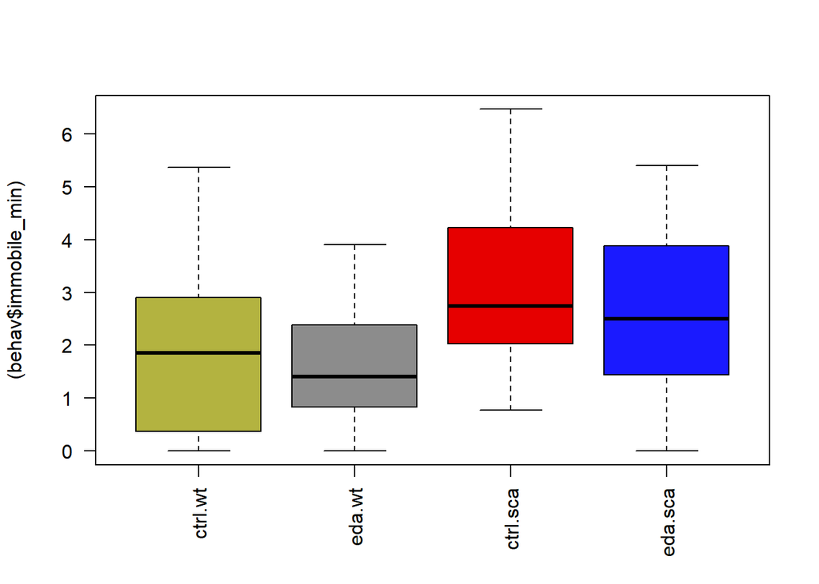

```r
plot((behav$immobile_min)~behav$group,las=2,xlab="",
     col=cola)
```

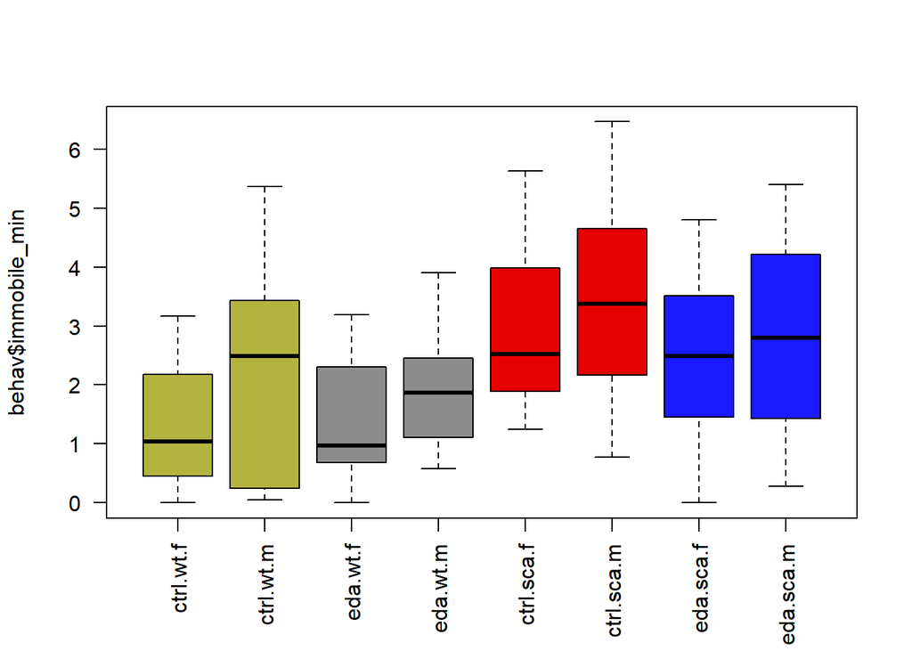

```r
plot(behav$immobile_min~behav$group_sex,las=2,xlab="",
     col=cola[c(1,1,2,2,3,3,4,4)])
```

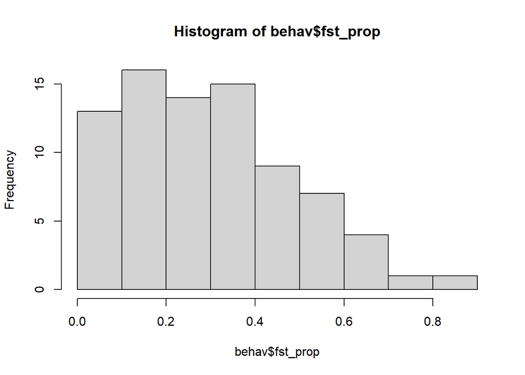

```r
hist(behav$fst_prop)
```

According to plots, male sex may increases the immobility. The sex-difference seems homogeneous across groups (NO sex interaction needed to include). Dispersion is not noticeably different among the groups.

## 3.2 Modelling

We will try fit the model using Gaussian as well as beta regression (as the outcome - the proportion of the immobility state - is bounded to 0 and 1, beta regression may be more natural). We will fit both and will check posterior predictive check (**PPC**) to explore how well the both models fit the data.

As there is indication of that male sex may be associated with an increaed immobility, we will fit two versions of model - one ignoring the sex effect, the second including the sex.

### 3.2.1 Prior specification

Lets look what should be prior for genotype effect, utilizing previous information from Tichanek et al.

Firstly, what should be prior for and intercept if we used Gaussian model?

```r
## re-setting reference group
behav$group<-relevel(behav$group,ref='ctrl.sca')

## defining the variable 'fst_immobility' in previously published data
young_scirep$fst_immobility <- (  ( 2+rowSums(young_scirep[,c(100:105)]) ) /360)

## mean immobility proportion in SCA1 mice
mean(young_scirep[young_scirep$genotype=="tg+",]$fst_immobility)
```

```
[1] 0.5163481
```

```r
## mean immobility proportion in our current data, acrros all groups
mean(behav$fst_prop)
```

```
[1] 0.2951266
```

```r
## standard deviation of the immobility proportion x 5 and 1.2
sd(behav$fst_prop)*c(5, 1.2)
```

```
[1] 0.9655930 0.2317423
```

```r
sd(young_scirep[young_scirep$genotype=="tg+",]$fst_immobility) * 1.2
```

```
[1] 0.2498246
```

*Mu* for intercept will be set to the value between 0.51 and 0.29, i.e. 0.4

*Sigma* for the intercept will be set to SD of the *fst_prop* x 5, i.e. 0.97

How to set prior for the genotype effect?

```r
## Model based on data of Tichanek et al.
model_fst<-glmmTMB(fst_immobility~genotype,data=young_scirep)

## model results
fixef(model_fst)
```

```
Conditional model:
(Intercept)    genotypew
     0.5163      -0.2571
```

```r
## What is reccomented prior?
prios(model_fst)
```

```
  Estimate
-0.1498014  0.2247021
```

For edaravone effect, we will use zero-effect-centered prior with *sigma* = 1.2 x SD of the outcome, i.e. 0.23

The same prior as for edaravone effect will be used also for the effect of male *sex*.

As we will fit 2 Gaussian models (one WITH *sex* effect, second ignoring the *sex*), we will define two priors.

```r
# prior01 - without sex
prior01 <- c(set_prior("student_t(3,0.4,0.97)", class = "b", coef = "Intercept"),
             set_prior("normal(-0.15,0.225)", class = "b", coef = "groupctrl.wt"),
             set_prior("normal(-0.15,0.225)", class = "b", coef = "groupeda.wt"),
             set_prior("normal(0,0.23)"    , class = "b", coef = "groupeda.sca"))

# prior02 - with sex
prior02 <- c(set_prior("student_t(3,0.4,0.97)", class = "b", coef = "Intercept"),
             set_prior("normal(-0.15,0.225)", class = "b", coef = "groupctrl.wt"),
             set_prior("normal(-0.15,0.225)", class = "b", coef = "groupeda.wt"),
             set_prior("normal(0,0.23)"    , class = "b", coef = "groupeda.sca"),
             set_prior("normal(0,0.23)"    , class = "b", coef = "sex_num"))
```

Similarly, we will define priors for beta models, using *prios* function and previous data, and using SD in the outcome variables

```r
## 'mu' for prior of intercept
mean(c(logit(mean(young_scirep[young_scirep$genotype=="tg+",]$fst_immobility)),
       logit(mean(behav$fst_prop))))
```

```
[1] -0.402599
```

```r
## 'sigma' for prior of intercept
sd(logit(behav$fst_prop))*5
```

```
[1] 7.147216
```

```r
## model with data from Tichanek et al. to get prior for genotype effect
model_of<-glmmTMB(fst_immobility~genotype,data=young_scirep,
                  family=beta_family(link="logit"))
summary(model_of)
```

```
 Family: beta  ( logit )
Formula:          fst_immobility ~ genotype
Data: young_scirep

     AIC      BIC   logLik deviance df.resid
   -25.4    -19.4     15.7    -31.4       52


Dispersion parameter for beta family (): 4.05

Conditional model:
            Estimate Std. Error z value Pr(>|z|)
(Intercept)  0.05222    0.16005   0.326    0.744
genotypew   -1.21502    0.25299  -4.803 1.57e-06 ***
---
Signif. codes:  0 '***' 0.001 '**' 0.01 '*' 0.05 '.' 0.1 ' ' 1
```

```r
prios(model_of)
```

```
  Estimate
-0.7191515  1.0787273
```

Defining the priors for beta regression models

```r
# without sex
prior03 <- c(set_prior("student_t(3,-0.4,7.14)", class = "b", coef = "Intercept"),
             set_prior("normal(-0.72,1.08)", class = "b", coef = "groupctrl.wt"),
             set_prior("normal(-0.72,1.08)", class = "b", coef = "groupeda.wt"),
             set_prior("normal(0,1.2)"  , class = "b", coef = "groupeda.sca"))

# sex included
prior04 <- c(set_prior("student_t(3,-0.4,7.14)", class = "b", coef = "Intercept"),
             set_prior("normal(-0.72,1.08)", class = "b", coef = "groupctrl.wt"),
             set_prior("normal(-0.72,1.08)", class = "b", coef = "groupeda.wt"),
             set_prior("normal(0,1.2)"  , class = "b", coef = "groupeda.sca"),
             set_prior("normal(0,1.2)"    , class = "b", coef = "sex_num"))
```

### 3.2.2 Fitting models ignoring sex

Now we have priors and can fit the models.

As we defined prior for *Intercept* term, we will include the formula *0 + Intercept*. We will use 8000 samples (from which 2000 will ‘warmup’ for mapping of probability landscape) per each of 2 chains. To reduce risk of convergence issues, we will increase ‘adapt_delta’ to 0.99 (default is 0.8)

At first, we will fit models ignoring the effect of *sex* and will firstlu decide whether to use Gaussian or beta model

```r
## Gaussian model without sex factor
fst_model_01 <- run_model(
              brm(fst_prop ~ 0+ Intercept+group,
                  data = behav,
                  prior = prior01,
                  family = "Gaussian", save_pars = save_pars(all = TRUE),
                  iter=8000, warmup=2000,chains=2,cores=1,seed=17,
                  control = list(adapt_delta = 0.99)),
                  'output/brm/fst_model_01', reuse = TRUE)

fst_model_02 <- run_model(
              brm(fst_prop ~0+Intercept+group,
                  data=behav, prior = prior03,
                  family=Beta(link="logit", link_phi="log"),
                  save_pars = save_pars(all = TRUE),
                  iter=8000, warmup=2000,chains=2,cores=1,seed=17,
                  control = list(adapt_delta = 0.99)),
                  'output/brm/fst_model_02', reuse = TRUE)
```

### 3.2.3 Diagnostics of models ignoring sex

We mean here diagnostics of convergence and sufficient size of posterior samples. We will use:

1. plotting trace of MCMC chains. Both chains should be mixed, the curves should be random without noticeable autocorrelations.
2. *Rhat* from model summary: 1 indicates convergence
3. *Bulk_ESS* and *Tail_ESS* from summary output: should be > 1000-2000, idealy more for paramters of interest

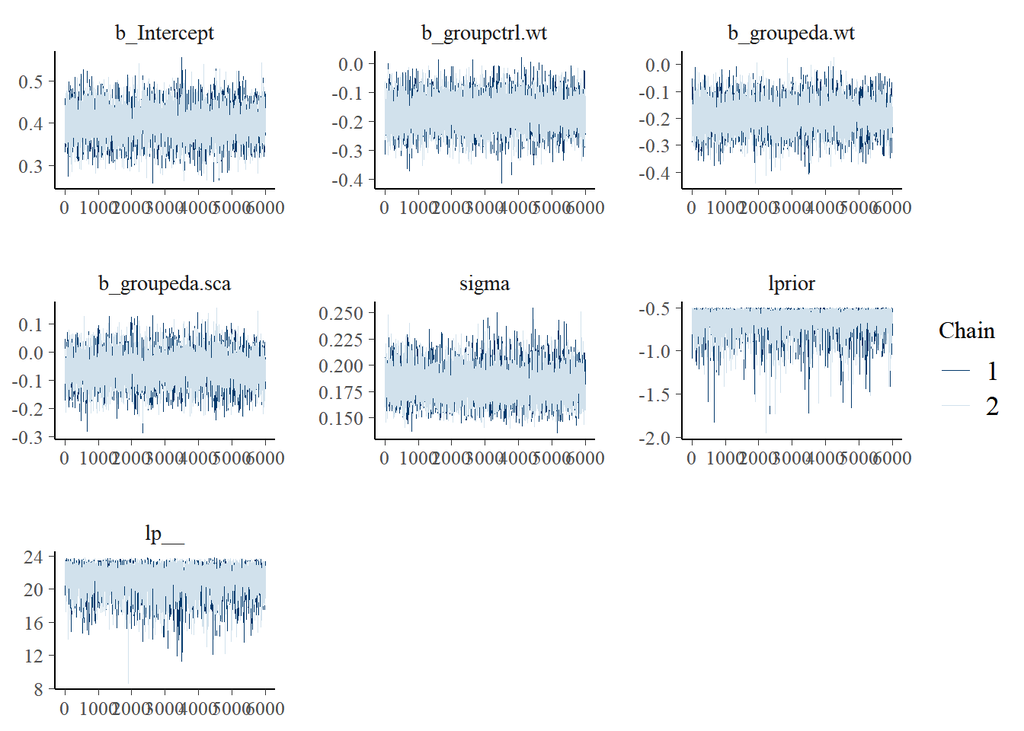

```r
## trace plots
mcmc_trace(fst_model_01)
```

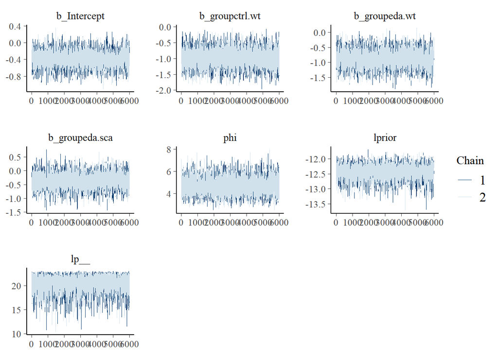

```r
mcmc_trace(fst_model_02)
```

```r
summary(fst_model_01)
```

```
 Family: gaussian
  Links: mu = identity; sigma = identity
Formula: fst_prop ~ 0 + Intercept + group
   Data: behav (Number of observations: 80)
  Draws: 2 chains, each with iter = 8000; warmup = 2000; thin = 1;
         total post-warmup draws = 12000

Population-Level Effects:
             Estimate Est.Error l-95% CI u-95% CI Rhat Bulk_ESS Tail_ESS
Intercept        0.40      0.04     0.32     0.48 1.00     3761     5572
groupctrl.wt    -0.17      0.05    -0.28    -0.06 1.00     4810     5778
groupeda.wt     -0.19      0.06    -0.30    -0.08 1.00     4393     6355
groupeda.sca    -0.06      0.05    -0.17     0.05 1.00     4847     6149

Family Specific Parameters:
      Estimate Est.Error l-95% CI u-95% CI Rhat Bulk_ESS Tail_ESS
sigma     0.18      0.02     0.16     0.21 1.00     7071     6983

Draws were sampled using sampling(NUTS). For each parameter, Bulk_ESS
and Tail_ESS are effective sample size measures, and Rhat is the potential
scale reduction factor on split chains (at convergence, Rhat = 1).
```

```r
summary(fst_model_01)
```

[output not shown]

Convergence of both models is fine

### 3.2.4 Posterior predictive checks

**data density**: the figure shows density of the outcome variable (thick line) and densities of artificial data from simulations based on Bayesian model estimates (slimmer lines). The thick line should not deviate much from the slimmer lines (in that case, model does not predict data well and does not fit the data appropriately).

However, if model includes random effect(s) (providing shrinkage), simulated and actual data may differ.

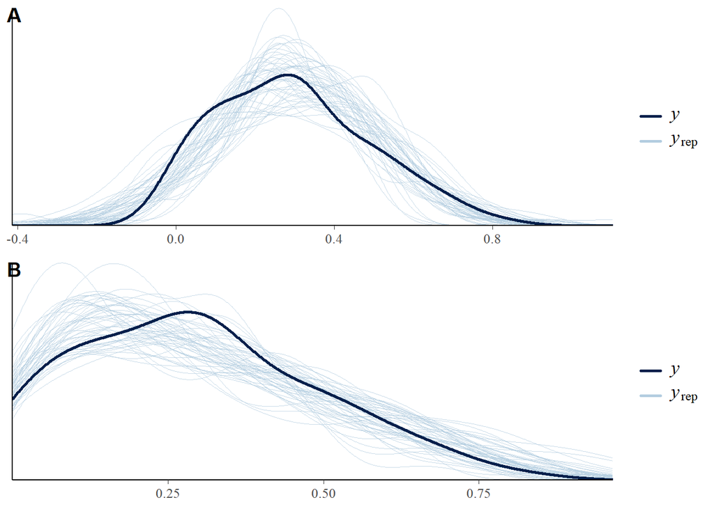

```r
pla<-pp_check(fst_model_01,type='dens_overlay',ndraws = 50)
plb<-pp_check(fst_model_02,type='dens_overlay',ndraws = 50)
plot_grid(pla, plb, labels=c("A", "B"), ncol = 1, nrow = 2)
```

Here, both Gaussian (A) and beta (B) models seems fine as they predict data well.

**grouped data density** shows the same as previous, but per group. This is useful for evaluation potential group-specific shapes of data distribution (e.g. different spread of outcome)

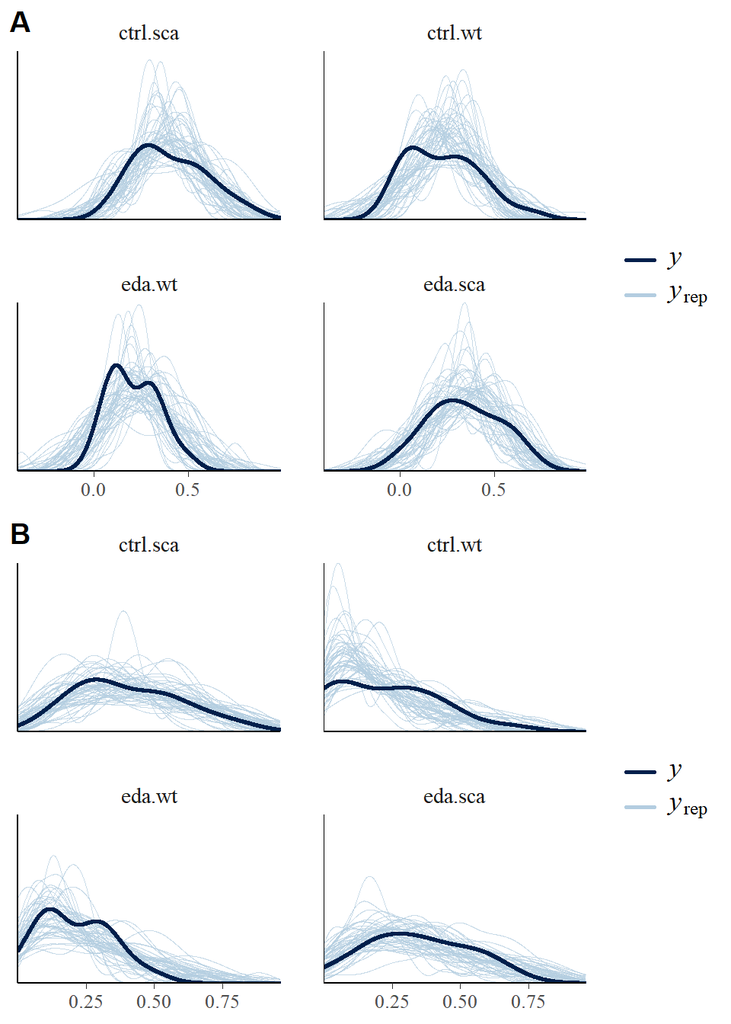

```r
pla<-pp_check(fst_model_01,type='dens_overlay_grouped',ndraws = 50,group='group')
plb<-pp_check(fst_model_02,type='dens_overlay_grouped',ndraws = 50,group='group')
plot_grid(pla, plb, labels=c("A", "B"), ncol = 1, nrow = 2)
```

Both models seem fine

**scatter plot** shows average predictions (x-axis) vs. data. For Gaussian models, moving along X-axis should not change spread of datapoints

```r
pla<-pp_check(fst_model_01,type='scatter_avg')
```

```
Using all posterior draws for ppc type 'scatter_avg' by default.
```

```r
plb<-pp_check(fst_model_02,type='scatter_avg')
```

```
Using all posterior draws for ppc type 'scatter_avg' by default.
```

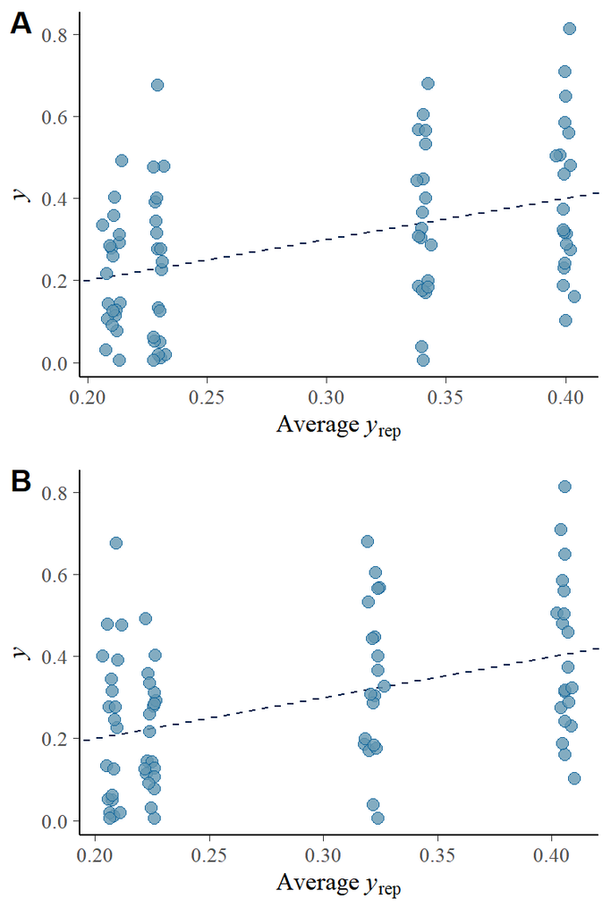

```r
plot_grid(pla, plb, labels=c("A", "B"), ncol = 1, nrow = 2)
```

Seems fine

**max, min** shows predicted vs. actual minimal and maximal value of outcome. Dark blue point should be among the light-blue points

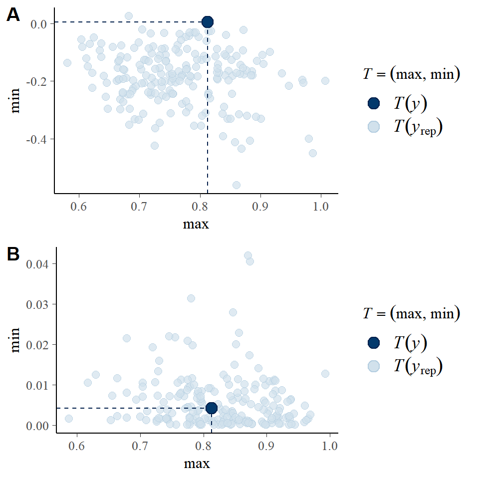

```r
pla<-pp_check(fst_model_01,type="stat_2d", stat = c("max", "min"),ndraws=200)
plb<-pp_check(fst_model_02,type="stat_2d", stat = c("max", "min"),ndraws=200)
plot_grid(pla, plb, labels=c("A", "B"), ncol = 1, nrow = 2)
```

We see that Gaussian model predicts smaller (negative) minimal values of the proportion. As the outcome is proportion which may start from zero, the prediction of negative values does not make sense. Beta regression does better work here

**mean, sd** shows predicted vs. actual mean and SD of the outcome

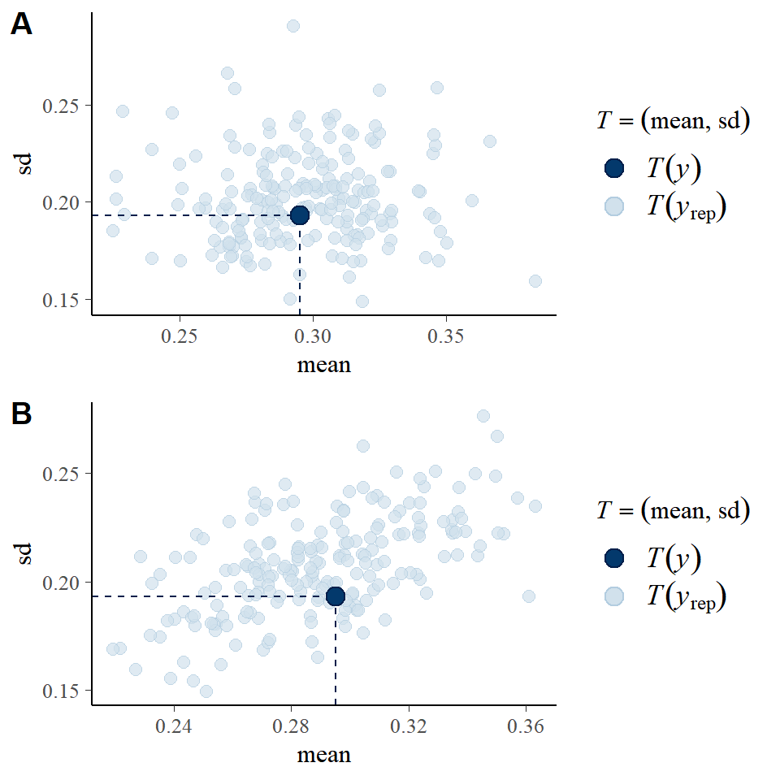

```r
pla<-pp_check(fst_model_01,type="stat_2d", stat = c("mean", "sd"),ndraws=200)
plb<-pp_check(fst_model_02,type="stat_2d", stat = c("mean", "sd"),ndraws=200)
plot_grid(pla, plb, labels=c("A", "B"), ncol = 1, nrow = 2)
```

Both models predict mean and SD well.

Are there too influential observations? All pareto estimates should have k < 0.7

```r
par(mfrow=c(1,2))
plot(loo(fst_model_01));loo(fst_model_01)
```

```
Computed from 12000 by 80 log-likelihood matrix

         Estimate   SE
elpd_loo     21.3  5.4
p_loo         4.4  0.7
looic       -42.6 10.9
------
Monte Carlo SE of elpd_loo is 0.0.

All Pareto k estimates are good (k < 0.5).
See help('pareto-k-diagnostic') for details.
```

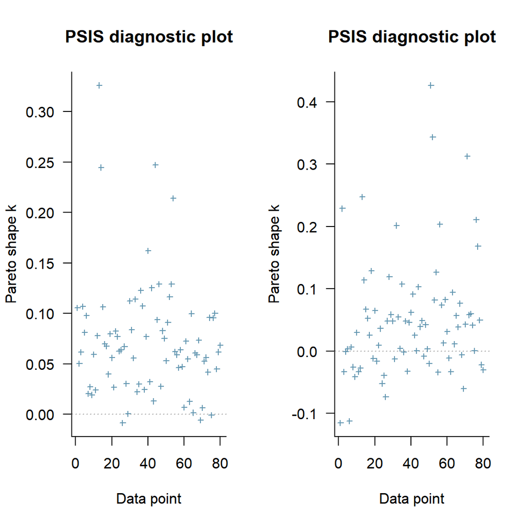

```
Computed from 12000 by 80 log-likelihood matrix

         Estimate   SE
elpd_loo     28.6  5.3
p_loo         5.2  1.3
looic       -57.3 10.6
------
Monte Carlo SE of elpd_loo is 0.0.

All Pareto k estimates are good (k < 0.5).
See help('pareto-k-diagnostic') for details.
```

```r
plot(loo(fst_model_02));loo(fst_model_02)
```

Seems fine

### 3.2.5 Model including sex

According to PPC, we can see that beta regression model the data more realistically and we will thus use beta regression model.

However, we observed that male sex may be associated with higher magnitude of immobility in the Forced Swimming Test. Should we include the sex factor to the model? We will use leave-one-out cross-validation (LOO-CV) to estimate whether such model provides more accurate out-of-sample prediction

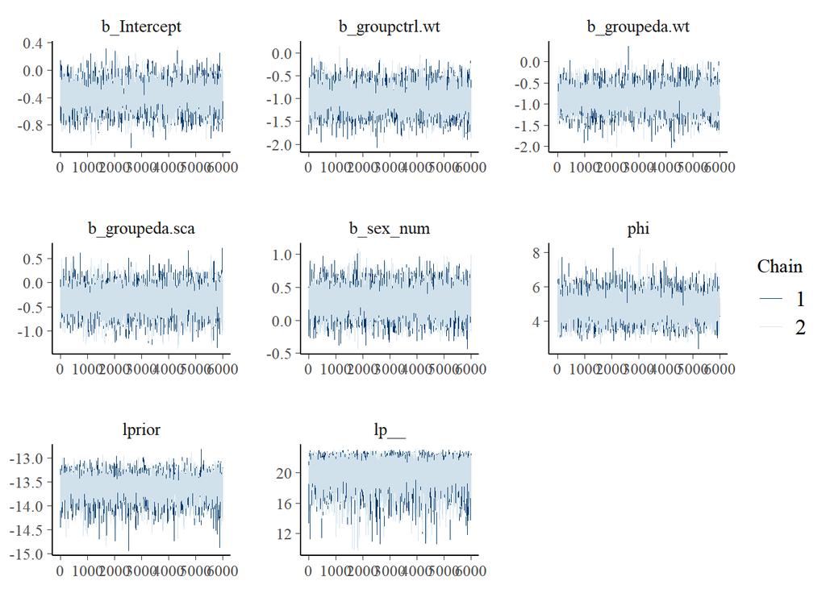

```r
fst_model_03 <- run_model(
            brm(fst_prop ~0+Intercept+group+sex_num,
                  data=behav, prior = prior04,
                  family=Beta(link="logit", link_phi="log"),
                  save_pars = save_pars(all = TRUE),
                  iter=8000, warmup=2000,chains=2,cores=1,seed=17,
                  control = list(adapt_delta = 0.99)),
                  'output/brm/fst_model_03', reuse = TRUE)

mcmc_trace(fst_model_03)
```

```r
summary(fst_model_03)
```

```
 Family: beta
  Links: mu = logit; phi = identity
Formula: fst_prop ~ 0 + Intercept + group + sex_num
   Data: behav (Number of observations: 80)
  Draws: 2 chains, each with iter = 8000; warmup = 2000; thin = 1;
         total post-warmup draws = 12000

Population-Level Effects:
             Estimate Est.Error l-95% CI u-95% CI Rhat Bulk_ESS Tail_ESS
Intercept       -0.38      0.18    -0.74    -0.03 1.00     4301     6277
groupctrl.wt    -1.00      0.27    -1.53    -0.47 1.00     5185     7459
groupeda.wt     -0.87      0.27    -1.41    -0.35 1.00     5272     6645
groupeda.sca    -0.37      0.26    -0.88     0.15 1.00     5253     6924
sex_num          0.29      0.20    -0.10     0.69 1.00     8590     7965

Family Specific Parameters:
    Estimate Est.Error l-95% CI u-95% CI Rhat Bulk_ESS Tail_ESS
phi     4.79      0.71     3.50     6.28 1.00     7624     7732

Draws were sampled using sampling(NUTS). For each parameter, Bulk_ESS
and Tail_ESS are effective sample size measures, and Rhat is the potential
scale reduction factor on split chains (at convergence, Rhat = 1).
```

Convergence of the model and effective size of samples are fine. Conclusions drawn by both beta models (ignoring vs. including sex) are basically the same. The decision thus have minimal practical implication.

Lets compare the models using the LOO-CV

```r
fst_model_02 <- add_criterion(fst_model_02, criterion = "loo")
fst_model_03 <- add_criterion(fst_model_03, criterion = "loo")
loo_compare(fst_model_02,fst_model_03)
```

```
             elpd_diff se_diff
fst_model_03  0.0       0.0
fst_model_02 -0.1       1.6
```

## 3.3 Posterior draws extraction

To visualize and summarize model, we will extract posterior samples of the between-groups difference.

```r
## data frame of posterior samples
post_fix<-as.data.frame(fst_model_02, variable = c("b_Intercept","b_groupctrl.wt",
                                                   "b_groupeda.wt","b_groupeda.sca"))
## re-naming the Intercept (= SCA_0 group)
names(post_fix)[1]<-"sca_ctrl"

## obtaining posterior samples/draws for group-specific proportion of immobility
post_fix$wt_ctrl<-post_fix$sca_ctrl+post_fix$b_groupctrl.wt
post_fix$wt_eda<-post_fix$sca_ctrl+post_fix$b_groupeda.wt
post_fix$sca_eda<-post_fix$sca_ctrl+post_fix$b_groupeda.sca

## differnce between WT_0 and WT_E group
post_fix$wt_contrast<-post_fix$wt_eda-post_fix$wt_ctrl

## obtaining median estimate and bound of 95% credible intervals
groupquant<-sapply(post_fix[,c(5,6,1,7)],function(p) quantile(p, probs = c(0.025,0.975,0.5)))

## the selected model is beta model with logit link. Lets to rescale prediction
## back to proportions
groupquant<-inv.logit(groupquant)
```

## 3.4 Data and model visualization

Next, we will visualize data and model. First plot will show data points and estimated prediction and 95% credible interval for the group prediction. The second will show posterior distribution of between-groups differences in the estimated proportion of time spent in immobility.

As we used beta model, we will show the effect (between-groups differences) in *odds ratio*, implying how many times are odds for being immobile in the given time different in one group compared to the second group. Thus, zero effect is OR = 1.

The second plot (posterior distributions) will include information about 95% credible interval about effect size and *probability of direction* (*PD*, i.e. probability that the effect goes in particular direction - is positive or negative). The higher *PD*, the higher estimated probability that there is difference between the groups.

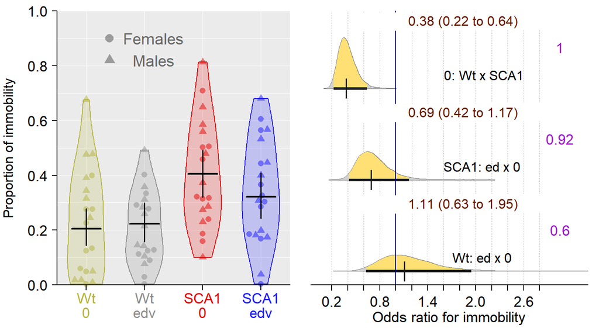

```r
## ordering of groups
behav$group<-factor(behav$group,levels=c('ctrl.wt','eda.wt','ctrl.sca','eda.sca'))

## setting spacing of plots
par(mfrow=c(1,2))
par(mar=c(2,3,0,0))
par(mgp=c(2,0.6,0))

## setting range of Y-axis
range<-c(0,1);scal<-range[2]-range[1]

## setting range of X-axis
xrange<-c(0.5,4.5);xscal=xrange[2]-xrange[1]

## plot
plot(NULL,xlim=c(xrange[1],xrange[2]),ylim=c(range[1],range[2]),xlab="",
     ylab="Proportion of immobility",las=1, axes=FALSE,cex.lab=1)

## adding grey background with white lines
rect(xrange[1],range[2],xrange[2],range[1],col="grey92",border=NA)
x<-range[1]
repeat{
  lines(c(xrange[1],xrange[2]),c(x,x),col="white",lwd=0.7)
  x=x+0.1;if(x>range[2]){break}}

x<-1
repeat{
  lines(c(x,x),c(range[1],range[2]),col="white",lwd=0.7)
  x=x+1;if(x>4.5){break}}

## showing distribution of data
vioplot(behav$fst_prop~behav$group,col=colb,at=c(1:4),add=T,
        border=cola,axes=FALSE,drawRect=F,lwd=1,wex=0.8)

## showing individual data points
beeswarm(behav$fst_prop~behav$group,col=colc,at=c(1:4),add=T,pwpch=(16.5+behav$sex_num) )

## showing group-specific predictions and 95% CI
tp<-groupquant[3,]
xx<-1;wid=0.25
repeat{
  lines(c(xx-wid,xx+wid),c(tp[xx],tp[xx]),lwd=2,col="black");
  lines(c(xx,xx),c(groupquant[1,xx],groupquant[2,xx]),lwd=1.7,col="black")
  xx<-xx+1
  if(xx>4){break}}

## providing axis
tckk=-0.02
axis(2,las=2,cex.axis=1.1,at=seq(range[1],range[2],by=0.2),
     labels=c(rep("",length(seq(range[1],range[2],by=0.2)))),pos=xrange[1],tck=tckk)
axis(2,las=2,cex.axis=1.1,at=seq(range[1],range[2],by=0.2),pos=xrange[1],tck=tckk)

axis(side=1,las=1,cex.axis=1.1,at=c(seq(1,4,by=1)),
     labels=c(rep("",length(seq(1,4,by=1)))),pos=range[1],tck=tckk)
lines(c(xrange[1],xrange[2]),c(range[1],range[1]))

## labelling the plot
text(c(1:4),c(rep(range[1]-0.046*scal,4)),xpd=T,cex=1.1,col=cola,
     c("Wt","Wt", "SCA1", "SCA1"))
ypo<-c(range[1]-0.1*scal,range[1]-0.1*scal)
text(c(1:4),c(ypo[1],ypo[2],ypo[1],ypo[2]),xpd=T,cex=1.1,col=cola,
     c("0","edv", "0", "edv"))

ypos<-0.9;xpos=1.4
points(xpos,ypos,pch=16,cex=1.4,col=rgb(0.4,0.4,0.4,alpha=0.6))
text(xpos+0.19*xscal,ypos,"Females",col="grey40",cex=1.2)
points(xpos,ypos-0.08*scal,pch=17,cex=1.4,col=rgb(0.4,0.4,0.4,alpha=0.6))
text(xpos+0.19*xscal,ypos-0.08*scal,"Males",col="grey40",cex=1.2)

## setting spacing pf the 2nd plot
par(mar=c(2,0,0,0))

## making data frame of effect sizes (groups differences)
dif<-data.frame(post_fix$wt_contrast,post_fix$b_groupeda.sca,
                post_fix$b_groupctrl.wt)

## rescaling the effect to Odds Ratio (from log(OR), i.e. log-odds)
dif<-exp(dif)

## x-label and tickmarks
yla<-"Odds ratio for immobility"
tckk=-0.018
ste<-seq(0.2,2.8,by=0.2)

## drawing the posterior distributions
mons_poste(dif,1)

## labelling the posterior distribution plots
zpos=seq(0,1,1/3)
xx=1;ind=0.3;xpol<-2.1
text(xpol,zpos[xx]+zpos[2]*ind,
     "Wt: ed x 0 ",cex=1)
xx=xx+1

text(xpol,zpos[xx]+zpos[2]*ind,
     "SCA1: ed x 0 ",cex=1)
xx=xx+1

text(xpol,zpos[xx]+zpos[2]*ind,
     "0: Wt x SCA1",cex=1)
```

## 3.5 Conclusion

It is clear that SCA1 mice (on saline) have clearly larger immobility, but the effect of edaravone is not clear (is uncertain) and likely span from edaravone treated SCA1 reaching 0.42 times to 1.17 times larger immobility

# 4 Sucrose preference

## 4.1 Data exploration

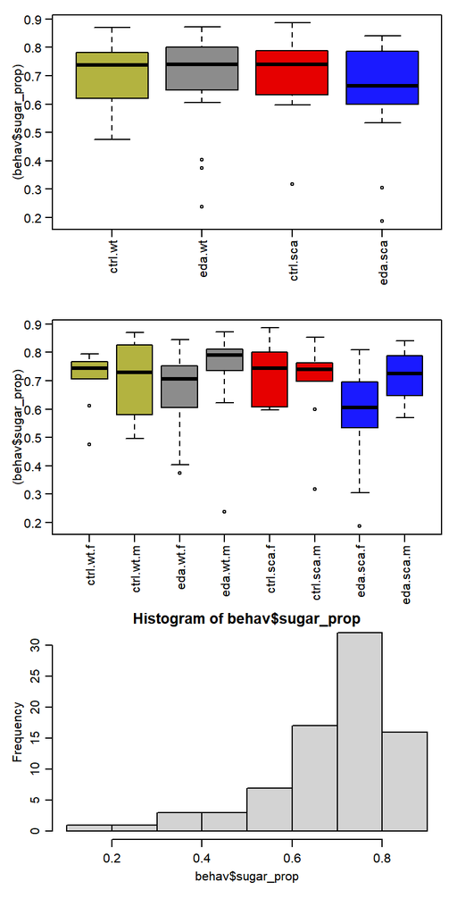

```r
par(mar=c(5,3.5,1,1))
par(mgp=c(1.9,0.7,0))
par(mfrow=c(3,1))

plot((behav$sugar_prop)~behav$group,las=2,xlab="",
     col=cola)

plot((behav$sugar_prop)~behav$group_sex,las=2,xlab="",
     col=cola[c(1,1,2,2,3,3,4,4)])

hist(behav$sugar_prop)
```

In contrast to FSR, there is no apparent and consistent effect of sex on the sucrose preference. The distribution seems as could be expected for proportions concentrated close to 0 or 1 (heavy tail in the direction toward 0.5).

There is no need to try to approximate the data with Gaussian distribution, beta regression is clear choice here.

## 4.2 Modelling

### 4.2.1 Prior specification

Due to methodological differences from sucrose test in Tichanek et al. and here, the previous results will not be used here for prior specification

```r
behav$group<-relevel(behav$group,ref='ctrl.sca')


logit(mean(behav[behav$genotype=="sca",]$sugar_prop))
```

```
[1] 0.7560386
```

```r
logit(mean(behav$sugar_prop))
```

```
[1] 0.7975844
```

```r
sd(logit(behav$sugar_prop))*5
```

```
[1] 3.49443
```

Prior specification

```r
prior01 <- c(set_prior("student_t(3,0.76,3.5)", class = "b", coef = "Intercept"),
             set_prior("normal(0,2)", class = "b", coef = "groupctrl.wt"),
             set_prior("normal(0,2)", class = "b", coef = "groupeda.wt"),
             set_prior("normal(0,1.2)"  , class = "b", coef = "groupeda.sca"))
```

### 4.2.2 Model fitting and diagnostics

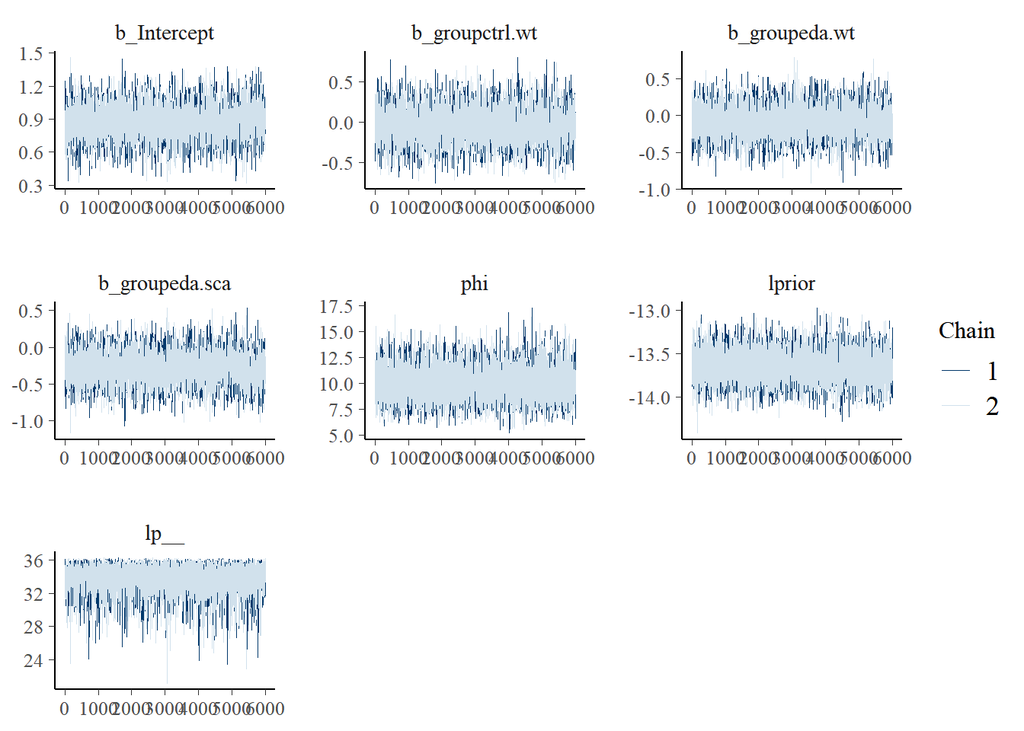

```r
sugar_model_01 <- run_model(
              brm(sugar_prop ~0+Intercept+group,
                  data=behav, prior = prior01,
                  family=Beta(link="logit", link_phi="log"),
                  save_pars = save_pars(all = TRUE),
                  iter=8000, warmup=2000,chains=2,cores=1,seed=17,
                  control = list(adapt_delta = 0.99)),
                  'output/brm/sugar_model_01', reuse = TRUE)

mcmc_trace(sugar_model_01)
```

```r
summary(sugar_model_01)
```

```
 Family: beta
  Links: mu = logit; phi = identity
Formula: sugar_prop ~ 0 + Intercept + group
   Data: behav (Number of observations: 80)
  Draws: 2 chains, each with iter = 8000; warmup = 2000; thin = 1;
         total post-warmup draws = 12000

Population-Level Effects:
             Estimate Est.Error l-95% CI u-95% CI Rhat Bulk_ESS Tail_ESS
Intercept        0.87      0.15     0.58     1.17 1.00     3651     5221
groupctrl.wt    -0.03      0.21    -0.44     0.38 1.00     4391     6377
groupeda.wt     -0.08      0.21    -0.49     0.33 1.00     4285     6284
groupeda.sca    -0.28      0.21    -0.68     0.12 1.00     4420     6172

Family Specific Parameters:
    Estimate Est.Error l-95% CI u-95% CI Rhat Bulk_ESS Tail_ESS
phi     9.94      1.55     7.17    13.27 1.00     6950     7110

Draws were sampled using sampling(NUTS). For each parameter, Bulk_ESS
and Tail_ESS are effective sample size measures, and Rhat is the potential
scale reduction factor on split chains (at convergence, Rhat = 1).
```

Convergence is fine, ESS are sufficient

### 4.2.3 PPC

Quick version of PPC

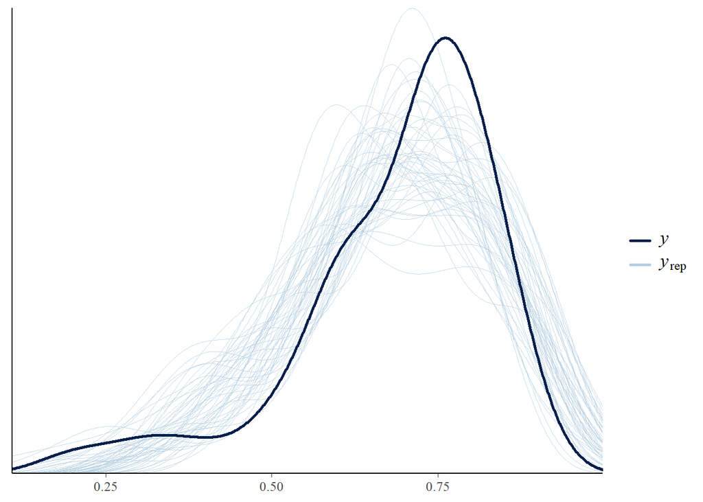

```r
pp_check(sugar_model_01,type='dens_overlay',ndraws = 50)
```

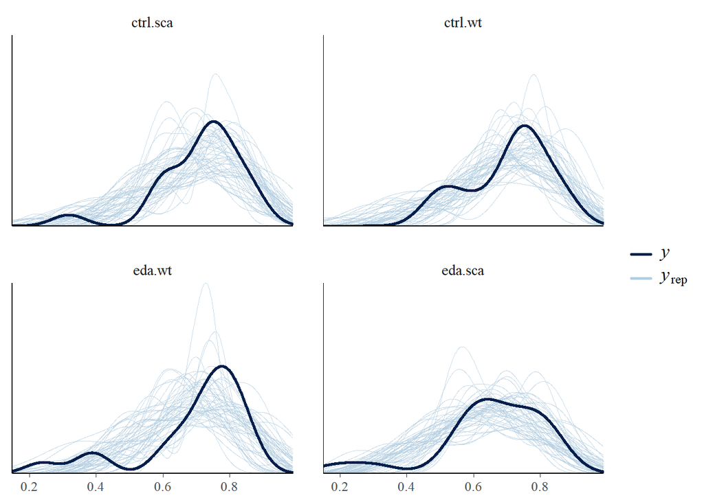

```r
pp_check(sugar_model_01,type='dens_overlay_grouped',ndraws = 50,group='group')
```

```
Using all posterior draws for ppc type 'scatter_avg' by default.
```

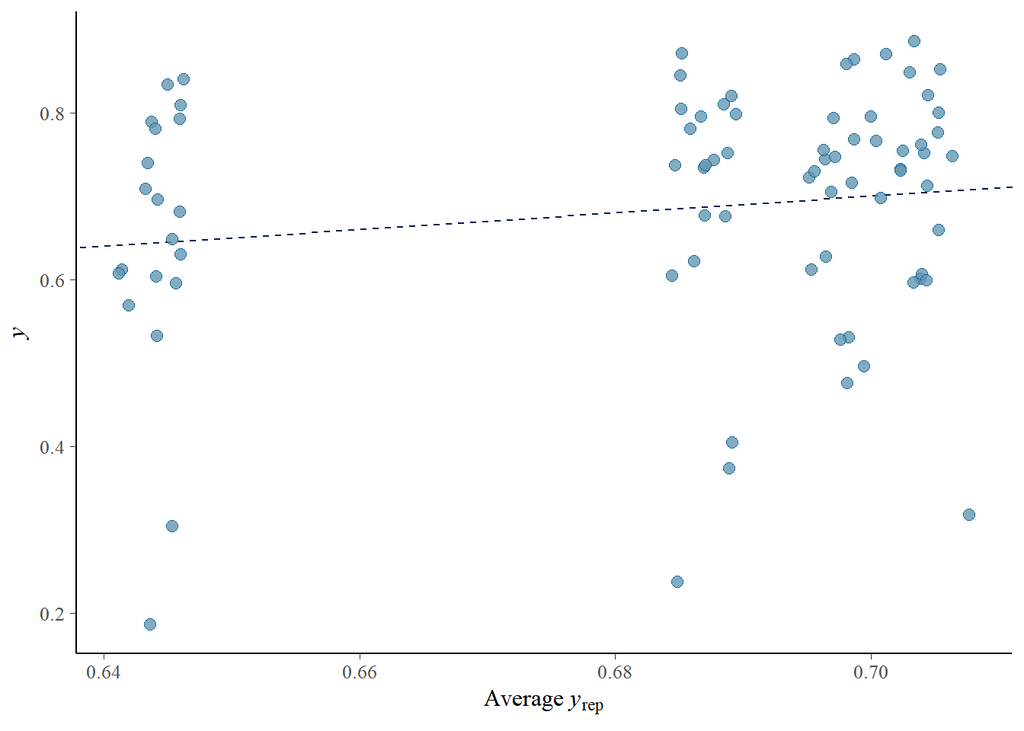

```r
pp_check(sugar_model_01,type='scatter_avg')
```

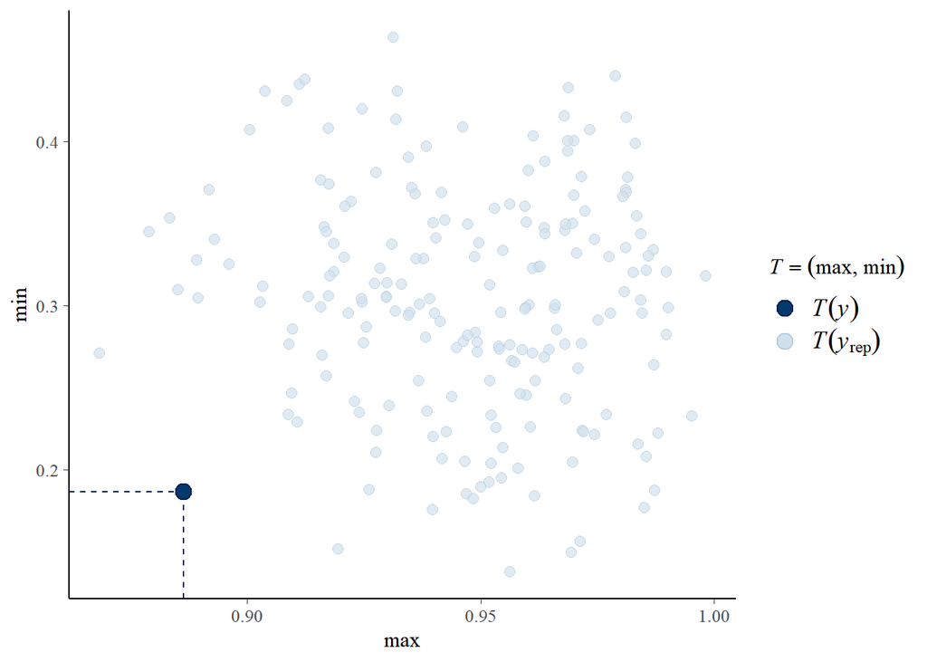

```r
pp_check(sugar_model_01,type="stat_2d", stat = c("max", "min"),ndraws=200)
```

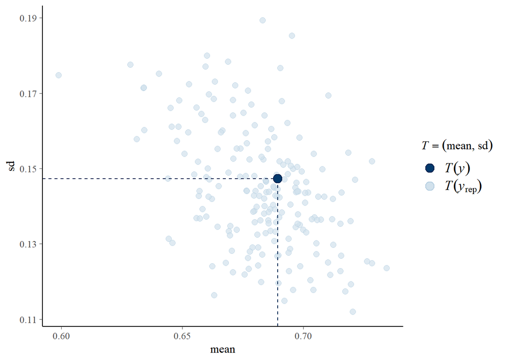

```r
pp_check(sugar_model_01,type="stat_2d", stat = c("mean", "sd"),ndraws=200)
```

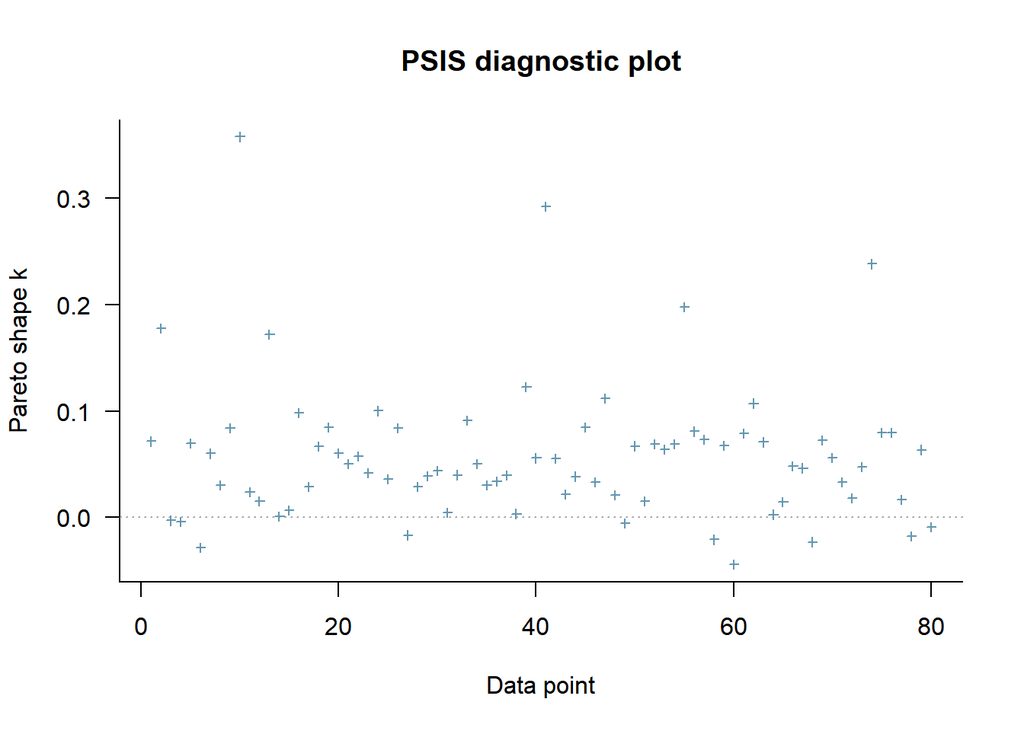

```
Computed from 12000 by 80 log-likelihood matrix

         Estimate   SE
elpd_loo     42.1  8.5
p_loo         5.4  1.4
looic       -84.3 16.9
------
Monte Carlo SE of elpd_loo is 0.0.

All Pareto k estimates are good (k < 0.5).
See help('pareto-k-diagnostic') for details.
```

```r
plot(loo(sugar_model_01));loo(sugar_model_01)
```

Diagnostics is not so nice as in previous example. E.g., max values are smaller than generally expected, especially when taking account low minimal values. So, the high range of the proportion seems to be sharply restricted but the low range seems to be unexpectedly low. This reduces reliability of the model.

Thus, if there was some suggestions of plausible effect, non-parametric estimation (based on non-parametric bootstrap) may provide useful validation. Here the effects seem negligible so no validation is necessary.

## 4.3 Posterior draws extraction

```r
post_fix<-as.data.frame(sugar_model_01, variable = c("b_Intercept","b_groupctrl.wt",
                                                   "b_groupeda.wt","b_groupeda.sca"))
names(post_fix)[1]<-"sca_ctrl"

post_fix$wt_ctrl<-post_fix$sca_ctrl+post_fix$b_groupctrl.wt
post_fix$wt_eda<-post_fix$sca_ctrl+post_fix$b_groupeda.wt
post_fix$sca_eda<-post_fix$sca_ctrl+post_fix$b_groupeda.sca
post_fix$wt_contrast<-post_fix$wt_eda-post_fix$wt_ctrl

groupquant<-sapply(post_fix[,c(5,6,1,7)],function(p) quantile(p, probs = c(0.025,0.975,0.5)))
groupquant<-inv.logit(groupquant)
```

## 4.4 Data and model vizualisation

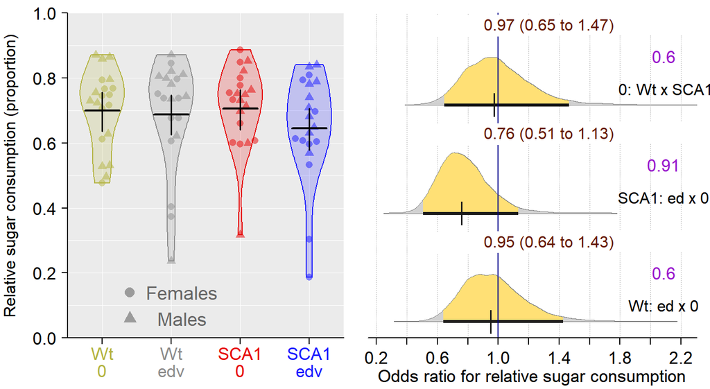

```r
behav$group<-factor(behav$group,levels=c('ctrl.wt','eda.wt','ctrl.sca','eda.sca'))

par(mfrow=c(1,2))
par(mar=c(2,3,0,0))
par(mgp=c(2,0.6,0))
range<-c(0,1);scal<-range[2]-range[1]
xrange<-c(0.5,4.5);xscal=xrange[2]-xrange[1]
plot(NULL,xlim=c(xrange[1],xrange[2]),ylim=c(range[1],range[2]),xlab="",
     ylab="Relative sugar consumption (proportion)",las=1, axes=FALSE,cex.lab=1)

rect(xrange[1],range[2],xrange[2],range[1],col="grey92",border=NA)
x<-range[1]
repeat{
  lines(c(xrange[1],xrange[2]),c(x,x),col="white",lwd=0.7)
  x=x+0.1;if(x>range[2]){break}}

x<-1
repeat{
  lines(c(x,x),c(range[1],range[2]),col="white",lwd=0.7)
  x=x+1;if(x>4.5){break}}

vioplot(behav$sugar_prop~behav$group,col=colb,at=c(1:4),add=T,
        border=cola,axes=FALSE,drawRect=F,lwd=1,wex=0.8)

beeswarm(behav$sugar_prop~behav$group,col=colc,at=c(1:4),add=T,pwpch=(16.5+behav$sex_num) )

tp<-groupquant[3,]
xx<-1;wid=0.25
repeat{
  lines(c(xx-wid,xx+wid),c(tp[xx],tp[xx]),lwd=2,col="black");
  lines(c(xx,xx),c(groupquant[1,xx],groupquant[2,xx]),lwd=1.7,col="black")
  xx<-xx+1
  if(xx>4){break}}

tckk=-0.02
axis(2,las=2,cex.axis=1.1,at=seq(range[1],range[2],by=0.2),
     labels=c(rep("",length(seq(range[1],range[2],by=0.2)))),pos=xrange[1],tck=tckk)
axis(2,las=2,cex.axis=1.1,at=seq(range[1],range[2],by=0.2),pos=xrange[1],tck=tckk)

axis(side=1,las=1,cex.axis=1.1,at=c(seq(1,4,by=1)),
     labels=c(rep("",length(seq(1,4,by=1)))),pos=range[1],tck=tckk)
lines(c(xrange[1],xrange[2]),c(range[1],range[1]))
text(c(1:4),c(rep(range[1]-0.046*scal,4)),xpd=T,cex=1.1,col=cola,
     c("Wt","Wt", "SCA1", "SCA1"))
ypo<-c(range[1]-0.1*scal,range[1]-0.1*scal)
text(c(1:4),c(ypo[1],ypo[2],ypo[1],ypo[2]),xpd=T,cex=1.1,col=cola,
     c("0","edv", "0", "edv"))

ypos<-0.14;xpos=1.4
points(xpos,ypos,pch=16,cex=1.4,col=rgb(0.4,0.4,0.4,alpha=0.6))
text(xpos+0.19*xscal,ypos,"Females",col="grey40",cex=1.2)
points(xpos,ypos-0.08*scal,pch=17,cex=1.4,col=rgb(0.4,0.4,0.4,alpha=0.6))
text(xpos+0.19*xscal,ypos-0.08*scal,"Males",col="grey40",cex=1.2)

# probability distributions
par(mar=c(2,0,0,0))
dif<-data.frame(post_fix$wt_contrast,post_fix$b_groupeda.sca,
                post_fix$b_groupctrl.wt)
dif<-exp(dif)
yla<-"Odds ratio for relative sugar consumption"
tckk=-0.018
ste<-seq(0.2,2.2,by=0.2)
mons_poste(dif,1)

zpos=seq(0,1,1/3)
xx=1;ind=0.3;xpol<-2.1
text(xpol,zpos[xx]+zpos[2]*ind,
     "Wt: ed x 0 ",cex=1)
xx=xx+1

text(xpol,zpos[xx]+zpos[2]*ind,
     "SCA1: ed x 0 ",cex=1)
xx=xx+1

text(xpol,zpos[xx]+zpos[2]*ind,
     "0: Wt x SCA1",cex=1)
```

# 5 Distance walked in open field

## 5.1 Data exploration

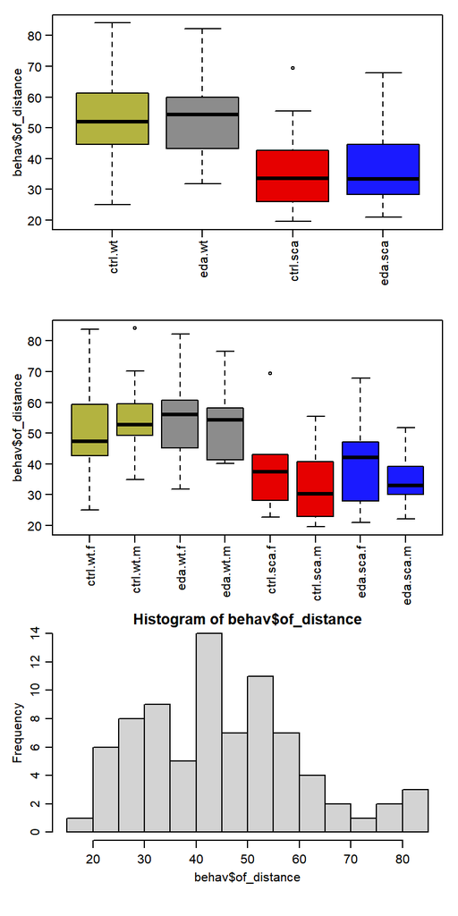

```r
## set spacing
par(mar=c(5,3.5,1,1))
par(mgp=c(1.9,0.7,0))
par(mfrow=c(3,1))

## plotting
plot(behav$of_distance~behav$group,las=2,xlab="",
     col=cola)

plot(behav$of_distance~behav$group_sex,las=2,xlab="",
     col=cola[c(1,1,2,2,3,3,4,4)])

hist(behav$of_distance, 20)
```

No apparent effect of sex. Distribution seems to be symmetric and could be potentially approximated via Gaussian distribution. Alternatively, distance walked may be modelled with Gamma distribution

## 5.2 Modelling

### 5.2.1 Prior specification

Exploring data to get prior for gamma model

```r
behav$group<-relevel(behav$group,ref='ctrl.sca')

log(mean(young_scirep[young_scirep$genotype=="tg+",]$of.distance)/100)
```

```
[1] 3.579207
```

```r
log(mean(behav$of_distance))
```

```
[1] 3.810714
```

```r
sd(log(behav$of_distance))*5
```

```
[1] 1.774265
```

```r
model_pri<-glmmTMB((of.distance/100)~genotype,family=Gamma(link="log"),data=young_scirep)
summary(model_pri)
```

```
 Family: Gamma  ( log )
Formula:          (of.distance/100) ~ genotype
Data: young_scirep

     AIC      BIC   logLik deviance df.resid
   453.9    459.9   -223.9    447.9       52


Dispersion estimate for Gamma family (sigma^2): 0.12

Conditional model:
            Estimate Std. Error z value Pr(>|z|)
(Intercept)  3.57921    0.06312   56.71  < 2e-16 ***
genotypew    0.38907    0.09362    4.16 3.24e-05 ***
---
Signif. codes:  0 '***' 0.001 '**' 0.01 '*' 0.05 '.' 0.1 ' ' 1
```

```r
prios(model_pri)
```

```
 Estimate
0.2055787 0.3083680
```

Setting the prior for gamma model

```r
prior01 <- c(set_prior("student_t(3, 3.7, 1.77)", class = "b", coef = "Intercept"),
             set_prior("normal(0.2,0.31)", class = "b", coef = "groupctrl.wt"),
             set_prior("normal(0.2,0.31)", class = "b", coef = "groupeda.wt"),
             set_prior("normal(0,1.2)"  , class = "b", coef = "groupeda.sca"))
```

Exploring data to get prior for Gaussian model

```r
sd(behav[behav$genotype=="sca",]$of_distance)*c(5, 1.2)
```

```
[1] 59.90019 14.37604
```

```r
sd(behav$of_distance)*c(5, 1.2)
```

```
[1] 77.94031 18.70568
```

```r
mean(c(mean(young_scirep[young_scirep$genotype=="tg+",]$of.distance/100),
mean(behav$of_distance)))
```

```
[1] 40.5139
```

```r
model_pri<-glmmTMB((of.distance/100)~genotype,data=young_scirep)
summary(model_pri)
```

```
 Family: gaussian  ( identity )
Formula:          (of.distance/100) ~ genotype
Data: young_scirep

     AIC      BIC   logLik deviance df.resid
   459.2    465.2   -226.6    453.2       52


Dispersion estimate for gaussian family (sigma^2):  222

Conditional model:
            Estimate Std. Error z value Pr(>|z|)
(Intercept)   35.845      2.718  13.186  < 2e-16 ***
genotypew     17.048      4.032   4.228 2.36e-05 ***
---
Signif. codes:  0 '***' 0.001 '**' 0.01 '*' 0.05 '.' 0.1 ' ' 1
```

```r
prios(model_pri)
```

```
 Estimate
 9.145387 13.718081
```

Prior for Gaussian model

```r
prior02 <- c(set_prior("student_t(3, 40.5, 60)", class = "b", coef = "Intercept"),
             set_prior("normal(9.1, 13.7)", class = "b", coef = "groupctrl.wt"),
             set_prior("normal(9.1, 13.7)", class = "b", coef = "groupeda.wt"),
             set_prior("normal(0, 14.4)"  , class = "b", coef = "groupeda.sca"))
```

## 5.3 Fitting models and checking convergence and ESS

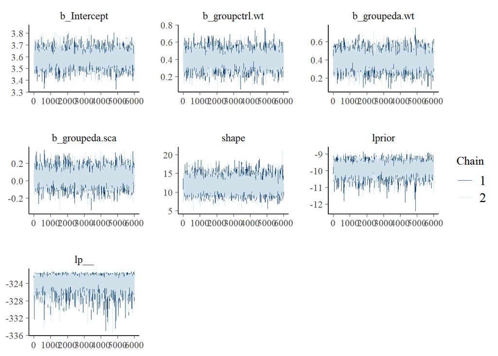

```r
of_dist_model_01 <- run_model(
            brm(of_distance ~0+Intercept+group,
                  data=behav, prior = prior01,
                  family=Gamma(link="log"),
                  save_pars = save_pars(all = TRUE),
                  iter=8000, warmup=2000,chains=2,cores=1,seed=17,
                  control = list(adapt_delta = 0.99)),
                  'output/brm/of_dist_model_01', reuse = TRUE)


of_dist_model_02 <- run_model(
              brm(of_distance~0+Intercept+group,
                    data=behav, prior = prior02,
                    family=gaussian(),
                    save_pars = save_pars(all = TRUE),
                    iter=8000, warmup=2000,chains=2,cores=1,seed=17,
                    control = list(adapt_delta = 0.99)),
                  'output/brm/of_dist_model_02', reuse = TRUE)

mcmc_trace(of_dist_model_01)
```

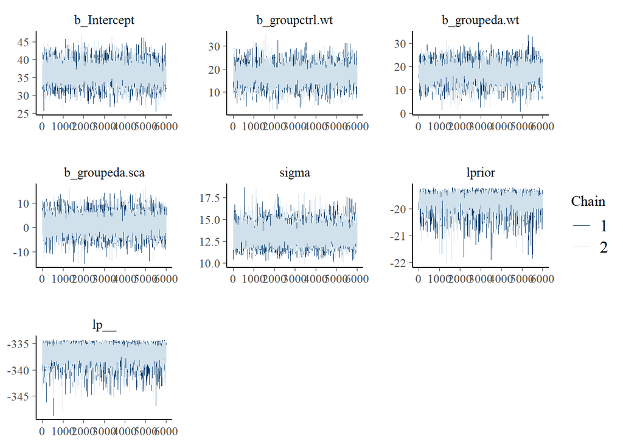

```r
mcmc_trace(of_dist_model_02)
```

```r
summary(of_dist_model_01)
```

```
 Family: gamma
  Links: mu = log; shape = identity
Formula: of_distance ~ 0 + Intercept + group
   Data: behav (Number of observations: 80)
  Draws: 2 chains, each with iter = 8000; warmup = 2000; thin = 1;
         total post-warmup draws = 12000

Population-Level Effects:
             Estimate Est.Error l-95% CI u-95% CI Rhat Bulk_ESS Tail_ESS
Intercept        3.58      0.06     3.46     3.71 1.00     3968     5799
groupctrl.wt     0.40      0.09     0.23     0.57 1.00     4820     6583
groupeda.wt      0.40      0.09     0.23     0.57 1.00     4636     6453
groupeda.sca     0.04      0.09    -0.13     0.22 1.00     4714     6283

Family Specific Parameters:
      Estimate Est.Error l-95% CI u-95% CI Rhat Bulk_ESS Tail_ESS
shape    11.80      1.86     8.48    15.81 1.00     7235     7319

Draws were sampled using sampling(NUTS). For each parameter, Bulk_ESS
and Tail_ESS are effective sample size measures, and Rhat is the potential
scale reduction factor on split chains (at convergence, Rhat = 1).
```

```r
summary(of_dist_model_02)
```

```
 Family: gaussian
  Links: mu = identity; sigma = identity
Formula: of_distance ~ 0 + Intercept + group
   Data: behav (Number of observations: 80)
  Draws: 2 chains, each with iter = 8000; warmup = 2000; thin = 1;
         total post-warmup draws = 12000

Population-Level Effects:
             Estimate Est.Error l-95% CI u-95% CI Rhat Bulk_ESS Tail_ESS
Intercept       36.17      2.80    30.71    41.71 1.00     3801     5160
groupctrl.wt    17.48      3.93     9.74    25.12 1.00     4274     5606
groupeda.wt     17.29      3.93     9.40    24.92 1.00     4828     6770
groupeda.sca     1.24      3.93    -6.46     9.05 1.00     4655     6255

Family Specific Parameters:
      Estimate Est.Error l-95% CI u-95% CI Rhat Bulk_ESS Tail_ESS
sigma    13.23      1.09    11.30    15.55 1.00     7418     6896

Draws were sampled using sampling(NUTS). For each parameter, Bulk_ESS
and Tail_ESS are effective sample size measures, and Rhat is the potential
scale reduction factor on split chains (at convergence, Rhat = 1).
```

Convergence and ESS are fine for both models.

## 5.4 PPC

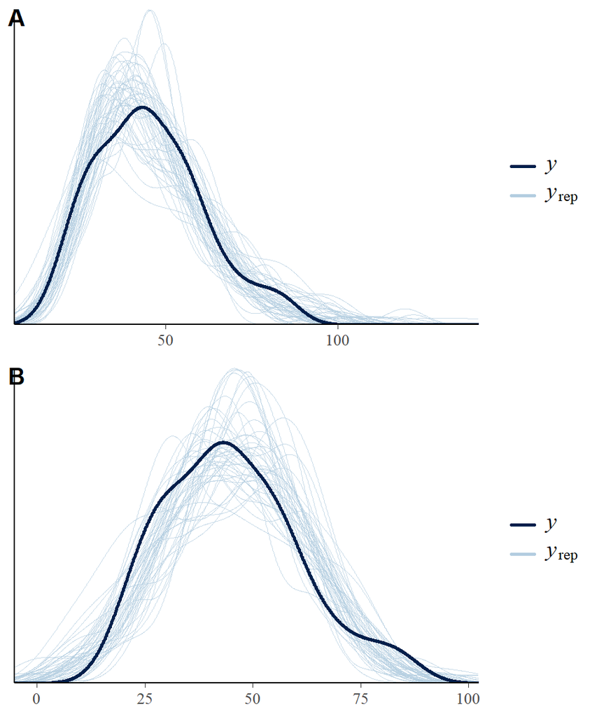

```r
pla<-pp_check(of_dist_model_01,type='dens_overlay',ndraws = 50)
plb<-pp_check(of_dist_model_02,type='dens_overlay',ndraws = 50)
plot_grid(pla, plb, labels=c("A", "B"), ncol = 1, nrow = 2)
```

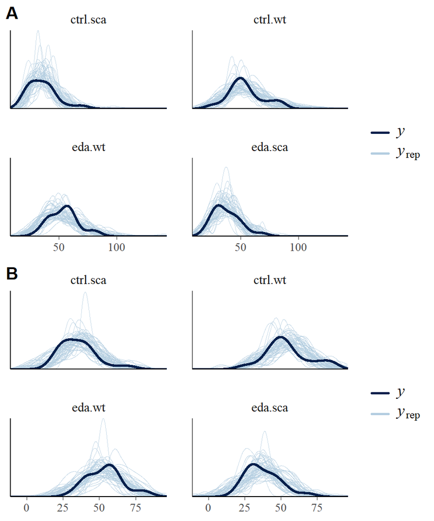

```r
pla<-pp_check(of_dist_model_01,type='dens_overlay_grouped',ndraws = 50,group='group')
plb<-pp_check(of_dist_model_02,type='dens_overlay_grouped',ndraws = 50,group='group')
plot_grid(pla, plb, labels=c("A", "B"), ncol = 1, nrow = 2)
```

```r
pla<-pp_check(of_dist_model_01,type='scatter_avg')
```

```
Using all posterior draws for ppc type 'scatter_avg' by default.
```

```r
plb<-pp_check(of_dist_model_02,type='scatter_avg')
```

```
Using all posterior draws for ppc type 'scatter_avg' by default.
```

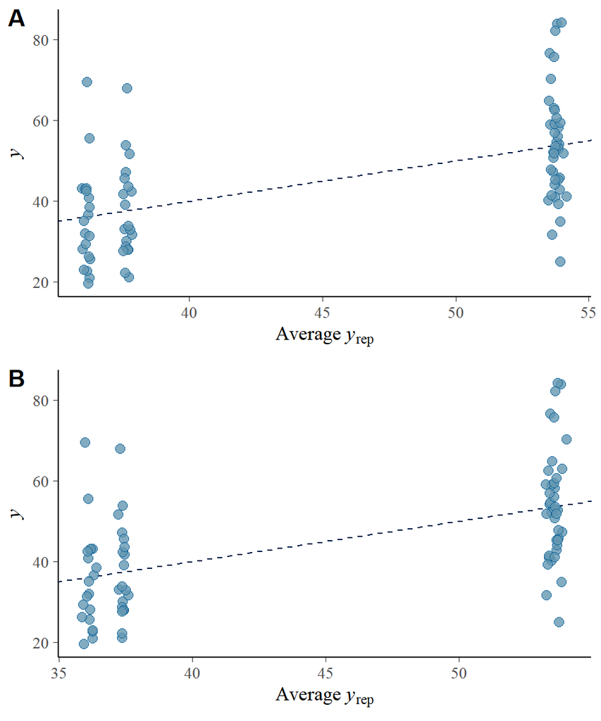

```r
plot_grid(pla, plb, labels=c("A", "B"), ncol = 1, nrow = 2)
```

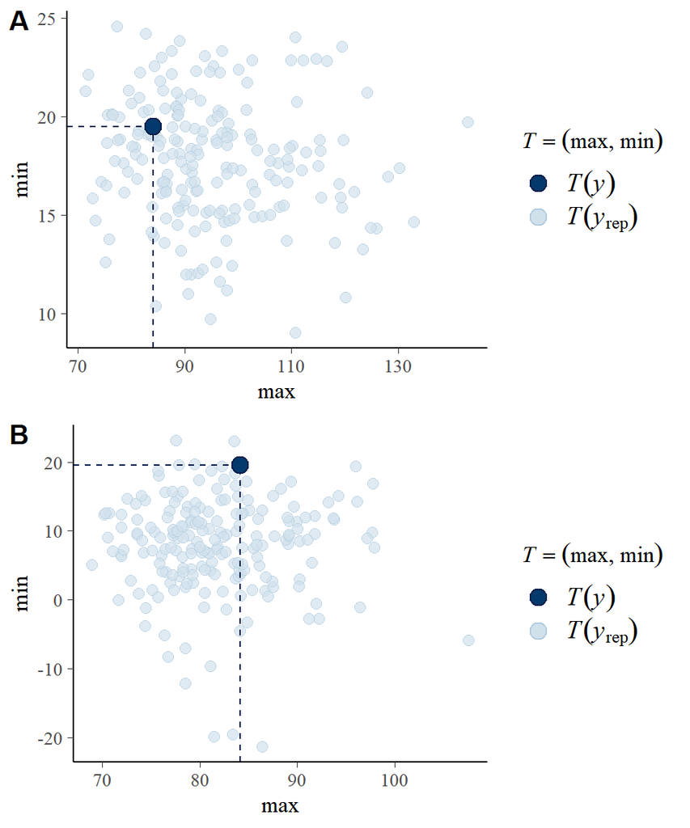

```r
pla<-pp_check(of_dist_model_01,type="stat_2d", stat = c("max", "min"),ndraws=200)
plb<-pp_check(of_dist_model_02,type="stat_2d", stat = c("max", "min"),ndraws=200)
plot_grid(pla, plb, labels=c("A", "B"), ncol = 1, nrow = 2)
```

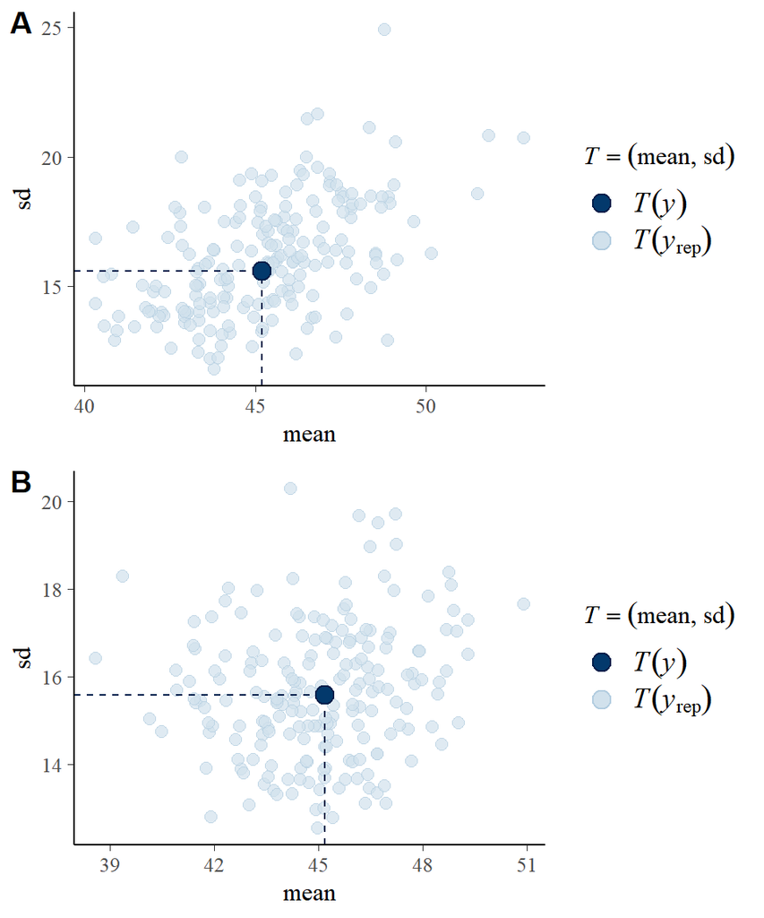

```r
pla<-pp_check(of_dist_model_01,type="stat_2d", stat = c("mean", "sd"),ndraws=200)
plb<-pp_check(of_dist_model_02,type="stat_2d", stat = c("mean", "sd"),ndraws=200)
plot_grid(pla, plb, labels=c("A", "B"), ncol = 1, nrow = 2)
```

```r
### Are there too influential observations?
par(mfrow=c(1,2))
plot(loo(of_dist_model_01));loo(of_dist_model_01)
```

```
Computed from 12000 by 80 log-likelihood matrix

         Estimate   SE
elpd_loo   -318.9  6.9
p_loo         4.7  0.9
looic       637.8 13.7
------
Monte Carlo SE of elpd_loo is 0.0.

All Pareto k estimates are good (k < 0.5).
See help('pareto-k-diagnostic') for details.
```

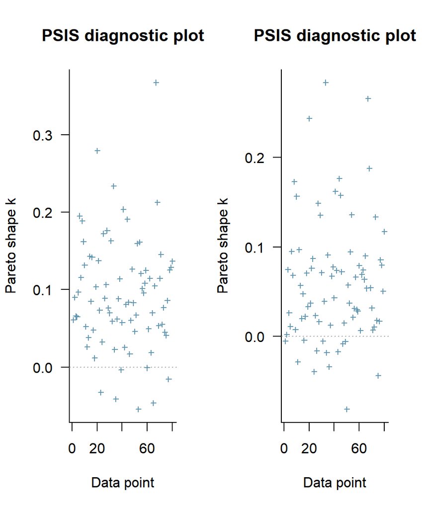

```
Computed from 12000 by 80 log-likelihood matrix

         Estimate   SE
elpd_loo   -322.1  7.0
p_loo         4.8  0.9
looic       644.3 13.9
------
Monte Carlo SE of elpd_loo is 0.0.

All Pareto k estimates are good (k < 0.5).
See help('pareto-k-diagnostic') for details.
```

```r
plot(loo(of_dist_model_02));loo(of_dist_model_02)
```

In both models, no observation has overly high influence. Gamma model seems to have slightly better PPC (at least in terms of predicted minimal value where Gaussian model sometimes predicts negative distance walked)

## 5.5 Posterior draws extraction and visualization

Posterior draws extraction. Note the we will use exponent of posterior prediction as we used log-link. Then, we will get fold-difference (fold-change) as an effect size, indicating how many time walked one group larger distance than the second group

```r
post_fix<-as.data.frame(of_dist_model_01, variable = c("b_Intercept","b_groupctrl.wt",
                                                   "b_groupeda.wt","b_groupeda.sca"))
names(post_fix)[1]<-"sca_ctrl"

post_fix$wt_ctrl<-post_fix$sca_ctrl+post_fix$b_groupctrl.wt
post_fix$wt_eda<-post_fix$sca_ctrl+post_fix$b_groupeda.wt
post_fix$sca_eda<-post_fix$sca_ctrl+post_fix$b_groupeda.sca
post_fix$wt_contrast<-post_fix$wt_eda-post_fix$wt_ctrl

groupquant<-sapply(post_fix[,c(5,6,1,7)],function(p) quantile(p, probs = c(0.025,0.975,0.5)))
groupquant<-exp(groupquant)
```

Visualization

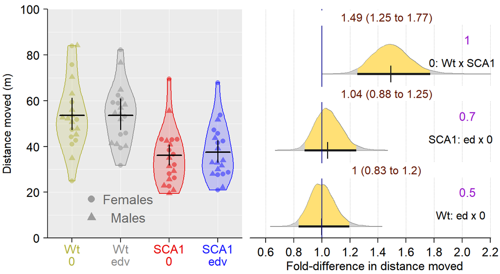

```r
behav$group<-factor(behav$group,levels=c('ctrl.wt','eda.wt','ctrl.sca','eda.sca'))

par(mfrow=c(1,2))
par(mar=c(2,3,0,0))
par(mgp=c(2,0.6,0))
range<-c(0,100);scal<-range[2]-range[1]
xrange<-c(0.5,4.5);xscal=xrange[2]-xrange[1]
plot(NULL,xlim=c(xrange[1],xrange[2]),ylim=c(range[1],range[2]),xlab="",
     ylab="Distance moved (m)",las=1, axes=FALSE,cex.lab=1)

rect(xrange[1],range[2],xrange[2],range[1],col="grey92",border=NA)
x<-range[1]
repeat{
  lines(c(xrange[1],xrange[2]),c(x,x),col="white",lwd=0.7)
  x=x+10;if(x>range[2]){break}}

x<-1
repeat{
  lines(c(x,x),c(range[1],range[2]),col="white",lwd=0.7)
  x=x+1;if(x>4.5){break}}

vioplot(behav$of_distance~behav$group,col=colb,at=c(1:4),add=T,
        border=cola,axes=FALSE,drawRect=F,lwd=1,wex=0.8)

beeswarm(behav$of_distance~behav$group,col=colc,at=c(1:4),add=T,pwpch=(16.5+behav$sex_num) )

tp<-(groupquant[3,])
xx<-1;wid=0.25
repeat{
  lines(c(xx-wid,xx+wid),c(tp[xx],tp[xx]),lwd=2,col="black");
  lines(c(xx,xx),c(groupquant[1,xx],groupquant[2,xx]),lwd=1.7,col="black")
  xx<-xx+1
  if(xx>4){break}}

tckk=-0.02
axis(2,las=2,cex.axis=1.1,at=seq(range[1],range[2],by=20),
     labels=c(rep("",length(seq(range[1],range[2],by=20)))),pos=xrange[1],tck=tckk)
axis(2,las=2,cex.axis=1.1,at=seq(range[1],range[2],by=20),pos=xrange[1],tck=tckk)

axis(side=1,las=1,cex.axis=1.1,at=c(seq(1,4,by=1)),
     labels=c(rep("",length(seq(1,4,by=1)))),pos=range[1],tck=tckk)
lines(c(xrange[1],xrange[2]),c(range[1],range[1]))
text(c(1:4),c(rep(range[1]-0.046*scal,4)),xpd=T,cex=1.1,col=cola,
     c("Wt","Wt", "SCA1", "SCA1"))
ypo<-c(range[1]-0.1*scal,range[1]-0.1*scal)
text(c(1:4),c(ypo[1],ypo[2],ypo[1],ypo[2]),xpd=T,cex=1.1,col=cola,
     c("0","edv", "0", "edv"))

ypos<-17;xpos=1.4
points(xpos,ypos,pch=16,cex=1.4,col=rgb(0.4,0.4,0.4,alpha=0.6))
text(xpos+0.19*xscal,ypos,"Females",col="grey40",cex=1.2)
points(xpos,ypos-0.08*scal,pch=17,cex=1.4,col=rgb(0.4,0.4,0.4,alpha=0.6))
text(xpos+0.19*xscal,ypos-0.08*scal,"Males",col="grey40",cex=1.2)

### probability distributions --------
par(mar=c(2,0,0,0))
dif<-data.frame(post_fix$wt_contrast,post_fix$b_groupeda.sca,
                post_fix$b_groupctrl.wt)
dif<-exp(dif)

yla<-"Fold-difference in distance moved"
tckk=-0.018
ste<-seq(0.2,2.2,by=0.2)
mons_poste(dif,1)

zpos=seq(0,1,1/3)
xx=1;ind=0.3;xpol<-2
text(xpol,zpos[xx]+zpos[2]*ind,
     "Wt: ed x 0 ",cex=1)
xx=xx+1

text(xpol,zpos[xx]+zpos[2]*ind,
     "SCA1: ed x 0 ",cex=1)
xx=xx+1

text(xpol,zpos[xx]+zpos[2]*ind,
     "0: Wt x SCA1",cex=1)
```